# Risk Factor Analysis

## Outcome Variable

**Outcome Variable:** pers_wast

## Predictor Variables

**Intervention Variable:** vagbrth

**Adjustment Set:**

- arm
- sex
- W_mage
- meducyrs
- feducyrs
- W_mhtcm
- W_mwtkg
- W_mbmi
- single
- brthmon
- delta_W_mage
- delta_meducyrs
- delta_feducyrs
- delta_W_mhtcm
- delta_W_mwtkg
- delta_W_mbmi
- delta_single
- delta_brthmon

## Stratifying Variables

The analysis was stratified on these variable(s):

- agecat
- studyid
- country

## Data Summary

| agecat | studyid | country | vagbrth | pers_wast | n_cell | n |
| --- | --- | --- | --- | --- | --- | --- |
| 0-24 months | ki1000108-CMC-V-BCS-2002 | INDIA | 0 | 0 | 24 | 373 |
| 0-24 months | ki1000108-CMC-V-BCS-2002 | INDIA | 0 | 1 | 1 | 373 |
| 0-24 months | ki1000108-CMC-V-BCS-2002 | INDIA | 1 | 0 | 326 | 373 |
| 0-24 months | ki1000108-CMC-V-BCS-2002 | INDIA | 1 | 1 | 22 | 373 |
| 0-24 months | ki1000108-IRC | INDIA | 0 | 0 | 62 | 410 |
| 0-24 months | ki1000108-IRC | INDIA | 0 | 1 | 8 | 410 |
| 0-24 months | ki1000108-IRC | INDIA | 1 | 0 | 300 | 410 |
| 0-24 months | ki1000108-IRC | INDIA | 1 | 1 | 40 | 410 |
| 0-24 months | ki1017093b-PROVIDE | BANGLADESH | 0 | 0 | 146 | 640 |
| 0-24 months | ki1017093b-PROVIDE | BANGLADESH | 0 | 1 | 2 | 640 |
| 0-24 months | ki1017093b-PROVIDE | BANGLADESH | 1 | 0 | 479 | 640 |
| 0-24 months | ki1017093b-PROVIDE | BANGLADESH | 1 | 1 | 13 | 640 |
| 0-24 months | ki1017093c-NIH-Crypto | BANGLADESH | 0 | 0 | 191 | 472 |
| 0-24 months | ki1017093c-NIH-Crypto | BANGLADESH | 0 | 1 | 3 | 472 |
| 0-24 months | ki1017093c-NIH-Crypto | BANGLADESH | 1 | 0 | 261 | 472 |
| 0-24 months | ki1017093c-NIH-Crypto | BANGLADESH | 1 | 1 | 17 | 472 |
| 0-24 months | ki1066203-TanzaniaChild2 | TANZANIA, UNITED REPUBLIC OF | 0 | 0 | 192 | 2140 |
| 0-24 months | ki1066203-TanzaniaChild2 | TANZANIA, UNITED REPUBLIC OF | 0 | 1 | 6 | 2140 |
| 0-24 months | ki1066203-TanzaniaChild2 | TANZANIA, UNITED REPUBLIC OF | 1 | 0 | 1890 | 2140 |
| 0-24 months | ki1066203-TanzaniaChild2 | TANZANIA, UNITED REPUBLIC OF | 1 | 1 | 52 | 2140 |
| 0-24 months | ki1119695-PROBIT | BELARUS | 0 | 0 | 1906 | 16581 |
| 0-24 months | ki1119695-PROBIT | BELARUS | 0 | 1 | 12 | 16581 |
| 0-24 months | ki1119695-PROBIT | BELARUS | 1 | 0 | 14516 | 16581 |
| 0-24 months | ki1119695-PROBIT | BELARUS | 1 | 1 | 147 | 16581 |
| 0-24 months | ki1126311-ZVITAMBO | ZIMBABWE | 0 | 0 | 797 | 9256 |
| 0-24 months | ki1126311-ZVITAMBO | ZIMBABWE | 0 | 1 | 8 | 9256 |
| 0-24 months | ki1126311-ZVITAMBO | ZIMBABWE | 1 | 0 | 8296 | 9256 |
| 0-24 months | ki1126311-ZVITAMBO | ZIMBABWE | 1 | 1 | 155 | 9256 |
| 0-24 months | kiGH5241-JiVitA-3 | BANGLADESH | 0 | 0 | 924 | 15644 |
| 0-24 months | kiGH5241-JiVitA-3 | BANGLADESH | 0 | 1 | 59 | 15644 |

[output cut: 74 more lines]

The following strata were considered:

- agecat: 0-24 months, studyid: ki1000108-CMC-V-BCS-2002, country: INDIA
- agecat: 0-24 months, studyid: ki1000108-IRC, country: INDIA
- agecat: 0-24 months, studyid: ki1017093b-PROVIDE, country: BANGLADESH
- agecat: 0-24 months, studyid: ki1017093c-NIH-Crypto, country: BANGLADESH
- agecat: 0-24 months, studyid: ki1066203-TanzaniaChild2, country: TANZANIA, UNITED REPUBLIC OF
- agecat: 0-24 months, studyid: ki1119695-PROBIT, country: BELARUS
- agecat: 0-24 months, studyid: ki1126311-ZVITAMBO, country: ZIMBABWE
- agecat: 0-24 months, studyid: kiGH5241-JiVitA-3, country: BANGLADESH
- agecat: 0-24 months, studyid: kiGH5241-JiVitA-4, country: BANGLADESH
- agecat: 0-6 months, studyid: ki1000108-CMC-V-BCS-2002, country: INDIA
- agecat: 0-6 months, studyid: ki1000108-IRC, country: INDIA
- agecat: 0-6 months, studyid: ki1017093b-PROVIDE, country: BANGLADESH
- agecat: 0-6 months, studyid: ki1017093c-NIH-Crypto, country: BANGLADESH
- agecat: 0-6 months, studyid: ki1066203-TanzaniaChild2, country: TANZANIA, UNITED REPUBLIC OF
- agecat: 0-6 months, studyid: ki1119695-PROBIT, country: BELARUS
- agecat: 0-6 months, studyid: ki1126311-ZVITAMBO, country: ZIMBABWE
- agecat: 0-6 months, studyid: kiGH5241-JiVitA-3, country: BANGLADESH
- agecat: 6-24 months, studyid: ki1000108-CMC-V-BCS-2002, country: INDIA
- agecat: 6-24 months, studyid: ki1000108-IRC, country: INDIA
- agecat: 6-24 months, studyid: ki1017093b-PROVIDE, country: BANGLADESH
- agecat: 6-24 months, studyid: ki1017093c-NIH-Crypto, country: BANGLADESH
- agecat: 6-24 months, studyid: ki1066203-TanzaniaChild2, country: TANZANIA, UNITED REPUBLIC OF
- agecat: 6-24 months, studyid: ki1119695-PROBIT, country: BELARUS
- agecat: 6-24 months, studyid: ki1126311-ZVITAMBO, country: ZIMBABWE
- agecat: 6-24 months, studyid: kiGH5241-JiVitA-3, country: BANGLADESH
- agecat: 6-24 months, studyid: kiGH5241-JiVitA-4, country: BANGLADESH

### Dropped Strata

Some strata were dropped due to rare outcomes:

- agecat: 0-24 months, studyid: ki1000108-CMC-V-BCS-2002, country: INDIA
- agecat: 0-24 months, studyid: ki1017093b-PROVIDE, country: BANGLADESH
- agecat: 0-24 months, studyid: ki1017093c-NIH-Crypto, country: BANGLADESH
- agecat: 0-6 months, studyid: ki1017093b-PROVIDE, country: BANGLADESH
- agecat: 0-6 months, studyid: ki1017093c-NIH-Crypto, country: BANGLADESH
- agecat: 0-6 months, studyid: ki1126311-ZVITAMBO, country: ZIMBABWE
- agecat: 0-6 months, studyid: kiGH5241-JiVitA-3, country: BANGLADESH
- agecat: 6-24 months, studyid: ki1000108-CMC-V-BCS-2002, country: INDIA
- agecat: 6-24 months, studyid: ki1017093b-PROVIDE, country: BANGLADESH
- agecat: 6-24 months, studyid: ki1017093c-NIH-Crypto, country: BANGLADESH

## Methods Detail

We’re interested in the causal parameters $E[Y_a]$ for all values of $a \in \mathcal{A}$. These parameters represent the mean outcome if, possibly contrary to fact, we intervened to set all units to have $A=a$. Under the randomization and positivity assumptions, these are identified by the statistical parameters $\psi_a=E_W[E_{Y|A,W}(Y|A=a,W)]$. In addition, we’re interested in the mean of $Y$, $E[Y]$ under no intervention (the observed mean). We will estimate these parameters by using SuperLearner to fit the relevant likelihood factors – $E_{Y|A,W}(Y|A=a,W)$ and $p(A=a|W)$, and then updating our likelihood fit using a joint TMLE.

For unadjusted analyses ($W=\{\}$), initial likelihoods were estimated using Lrnr_glm to estimate the simple $E(Y|A)$ and Lrnr_mean to estimate $p(A)$. For adjusted analyses, a small library containing Lrnr_glmnet, Lrnr_xgboost, and Lrnr_mean was used.

Having estimated these parameters, we will then use the delta method to estimate relative risks and attributable risks relative to a prespecified baseline level of $A$.

# Results Detail

## Results Plots

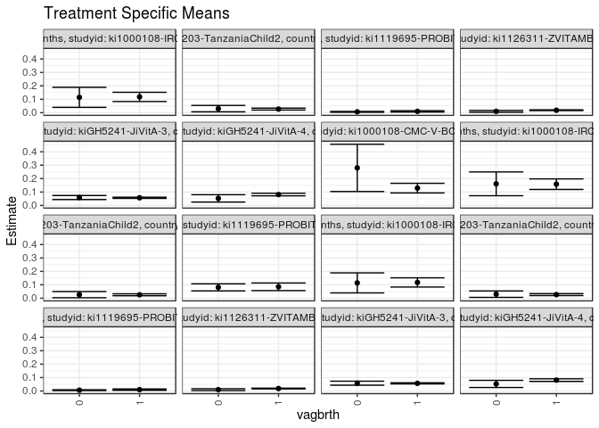

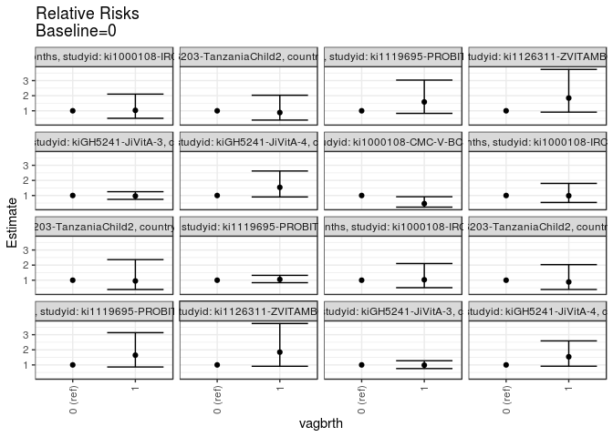

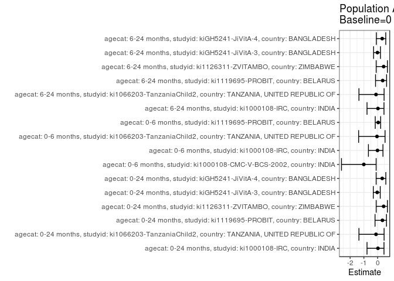

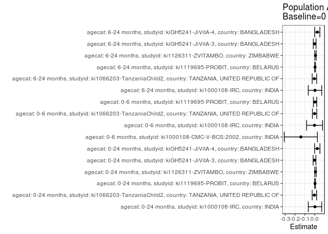

## Results Table

### Parameter: TSM

| agecat | studyid | country | intervention_level | baseline_level | estimate | ci_lower | ci_upper |
| --- | --- | --- | --- | --- | --- | --- | --- |
| 0-24 months | ki1000108-IRC | INDIA | 0 | NA | 0.1142857 | 0.0396628 | 0.1889086 |
| 0-24 months | ki1000108-IRC | INDIA | 1 | NA | 0.1176471 | 0.0833584 | 0.1519357 |
| 0-24 months | ki1066203-TanzaniaChild2 | TANZANIA, UNITED REPUBLIC OF | 0 | NA | 0.0303030 | 0.0064206 | 0.0541854 |
| 0-24 months | ki1066203-TanzaniaChild2 | TANZANIA, UNITED REPUBLIC OF | 1 | NA | 0.0267765 | 0.0195951 | 0.0339579 |
| 0-24 months | ki1119695-PROBIT | BELARUS | 0 | NA | 0.0062459 | 0.0030406 | 0.0094513 |
| 0-24 months | ki1119695-PROBIT | BELARUS | 1 | NA | 0.0099124 | 0.0051939 | 0.0146310 |
| 0-24 months | ki1126311-ZVITAMBO | ZIMBABWE | 0 | NA | 0.0099379 | 0.0030853 | 0.0167904 |
| 0-24 months | ki1126311-ZVITAMBO | ZIMBABWE | 1 | NA | 0.0183410 | 0.0154801 | 0.0212020 |
| 0-24 months | kiGH5241-JiVitA-3 | BANGLADESH | 0 | NA | 0.0590461 | 0.0439812 | 0.0741110 |
| 0-24 months | kiGH5241-JiVitA-3 | BANGLADESH | 1 | NA | 0.0570283 | 0.0528591 | 0.0611975 |
| 0-24 months | kiGH5241-JiVitA-4 | BANGLADESH | 0 | NA | 0.0526594 | 0.0253502 | 0.0799685 |
| 0-24 months | kiGH5241-JiVitA-4 | BANGLADESH | 1 | NA | 0.0810795 | 0.0714930 | 0.0906660 |
| 0-6 months | ki1000108-CMC-V-BCS-2002 | INDIA | 0 | NA | 0.2800000 | 0.1037493 | 0.4562507 |
| 0-6 months | ki1000108-CMC-V-BCS-2002 | INDIA | 1 | NA | 0.1291291 | 0.0930611 | 0.1651972 |
| 0-6 months | ki1000108-IRC | INDIA | 0 | NA | 0.1610014 | 0.0724243 | 0.2495785 |
| 0-6 months | ki1000108-IRC | INDIA | 1 | NA | 0.1585272 | 0.1192841 | 0.1977703 |
| 0-6 months | ki1066203-TanzaniaChild2 | TANZANIA, UNITED REPUBLIC OF | 0 | NA | 0.0267380 | 0.0036113 | 0.0498646 |
| 0-6 months | ki1066203-TanzaniaChild2 | TANZANIA, UNITED REPUBLIC OF | 1 | NA | 0.0254329 | 0.0182532 | 0.0326126 |
| 0-6 months | ki1119695-PROBIT | BELARUS | 0 | NA | 0.0809767 | 0.0546497 | 0.1073038 |
| 0-6 months | ki1119695-PROBIT | BELARUS | 1 | NA | 0.0851432 | 0.0567046 | 0.1135817 |
| 6-24 months | ki1000108-IRC | INDIA | 0 | NA | 0.1142857 | 0.0396628 | 0.1889086 |
| 6-24 months | ki1000108-IRC | INDIA | 1 | NA | 0.1176471 | 0.0833584 | 0.1519357 |
| 6-24 months | ki1066203-TanzaniaChild2 | TANZANIA, UNITED REPUBLIC OF | 0 | NA | 0.0303030 | 0.0064206 | 0.0541854 |
| 6-24 months | ki1066203-TanzaniaChild2 | TANZANIA, UNITED REPUBLIC OF | 1 | NA | 0.0267765 | 0.0195951 | 0.0339579 |
| 6-24 months | ki1119695-PROBIT | BELARUS | 0 | NA | 0.0060647 | 0.0028995 | 0.0092300 |
| 6-24 months | ki1119695-PROBIT | BELARUS | 1 | NA | 0.0099713 | 0.0052350 | 0.0147076 |
| 6-24 months | ki1126311-ZVITAMBO | ZIMBABWE | 0 | NA | 0.0099379 | 0.0030853 | 0.0167904 |
| 6-24 months | ki1126311-ZVITAMBO | ZIMBABWE | 1 | NA | 0.0183410 | 0.0154801 | 0.0212020 |
| 6-24 months | kiGH5241-JiVitA-3 | BANGLADESH | 0 | NA | 0.0580321 | 0.0431399 | 0.0729244 |
| 6-24 months | kiGH5241-JiVitA-3 | BANGLADESH | 1 | NA | 0.0570427 | 0.0528751 | 0.0612103 |
| 6-24 months | kiGH5241-JiVitA-4 | BANGLADESH | 0 | NA | 0.0526684 | 0.0260013 | 0.0793355 |
| 6-24 months | kiGH5241-JiVitA-4 | BANGLADESH | 1 | NA | 0.0810777 | 0.0714950 | 0.0906603 |

### Parameter: E(Y)

| agecat | studyid | country | intervention_level | baseline_level | estimate | ci_lower | ci_upper |
| --- | --- | --- | --- | --- | --- | --- | --- |
| 0-24 months | ki1000108-IRC | INDIA | NA | NA | 0.1170732 | 0.0859146 | 0.1482317 |
| 0-24 months | ki1066203-TanzaniaChild2 | TANZANIA, UNITED REPUBLIC OF | NA | NA | 0.0271028 | 0.0202213 | 0.0339843 |
| 0-24 months | ki1119695-PROBIT | BELARUS | NA | NA | 0.0095893 | 0.0052864 | 0.0138922 |
| 0-24 months | ki1126311-ZVITAMBO | ZIMBABWE | NA | NA | 0.0176102 | 0.0149305 | 0.0202899 |
| 0-24 months | kiGH5241-JiVitA-3 | BANGLADESH | NA | NA | 0.0572104 | 0.0531179 | 0.0613029 |
| 0-24 months | kiGH5241-JiVitA-4 | BANGLADESH | NA | NA | 0.0787756 | 0.0696990 | 0.0878522 |
| 0-6 months | ki1000108-CMC-V-BCS-2002 | INDIA | NA | NA | 0.1396648 | 0.1037072 | 0.1756225 |
| 0-6 months | ki1000108-IRC | INDIA | NA | NA | 0.1592040 | 0.1233945 | 0.1950135 |
| 0-6 months | ki1066203-TanzaniaChild2 | TANZANIA, UNITED REPUBLIC OF | NA | NA | 0.0255528 | 0.0186952 | 0.0324104 |
| 0-6 months | ki1119695-PROBIT | BELARUS | NA | NA | 0.0846069 | 0.0570929 | 0.1121208 |
| 6-24 months | ki1000108-IRC | INDIA | NA | NA | 0.1170732 | 0.0859146 | 0.1482317 |
| 6-24 months | ki1066203-TanzaniaChild2 | TANZANIA, UNITED REPUBLIC OF | NA | NA | 0.0271028 | 0.0202213 | 0.0339843 |
| 6-24 months | ki1119695-PROBIT | BELARUS | NA | NA | 0.0095893 | 0.0052864 | 0.0138922 |
| 6-24 months | ki1126311-ZVITAMBO | ZIMBABWE | NA | NA | 0.0176102 | 0.0149305 | 0.0202899 |
| 6-24 months | kiGH5241-JiVitA-3 | BANGLADESH | NA | NA | 0.0572104 | 0.0531179 | 0.0613029 |
| 6-24 months | kiGH5241-JiVitA-4 | BANGLADESH | NA | NA | 0.0787756 | 0.0696990 | 0.0878522 |

### Parameter: RR

| agecat | studyid | country | intervention_level | baseline_level | estimate | ci_lower | ci_upper |
| --- | --- | --- | --- | --- | --- | --- | --- |
| 0-24 months | ki1000108-IRC | INDIA | 0 | 0 | 1.0000000 | 1.0000000 | 1.0000000 |
| 0-24 months | ki1000108-IRC | INDIA | 1 | 0 | 1.0294118 | 0.5035574 | 2.1044047 |
| 0-24 months | ki1066203-TanzaniaChild2 | TANZANIA, UNITED REPUBLIC OF | 0 | 0 | 1.0000000 | 1.0000000 | 1.0000000 |
| 0-24 months | ki1066203-TanzaniaChild2 | TANZANIA, UNITED REPUBLIC OF | 1 | 0 | 0.8836251 | 0.3843408 | 2.0315133 |
| 0-24 months | ki1119695-PROBIT | BELARUS | 0 | 0 | 1.0000000 | 1.0000000 | 1.0000000 |
| 0-24 months | ki1119695-PROBIT | BELARUS | 1 | 0 | 1.5870181 | 0.8297329 | 3.0354662 |
| 0-24 months | ki1126311-ZVITAMBO | ZIMBABWE | 0 | 0 | 1.0000000 | 1.0000000 | 1.0000000 |
| 0-24 months | ki1126311-ZVITAMBO | ZIMBABWE | 1 | 0 | 1.8455656 | 0.9101236 | 3.7424724 |
| 0-24 months | kiGH5241-JiVitA-3 | BANGLADESH | 0 | 0 | 1.0000000 | 1.0000000 | 1.0000000 |
| 0-24 months | kiGH5241-JiVitA-3 | BANGLADESH | 1 | 0 | 0.9658260 | 0.7453648 | 1.2514943 |
| 0-24 months | kiGH5241-JiVitA-4 | BANGLADESH | 0 | 0 | 1.0000000 | 1.0000000 | 1.0000000 |
| 0-24 months | kiGH5241-JiVitA-4 | BANGLADESH | 1 | 0 | 1.5396973 | 0.9038131 | 2.6229623 |
| 0-6 months | ki1000108-CMC-V-BCS-2002 | INDIA | 0 | 0 | 1.0000000 | 1.0000000 | 1.0000000 |
| 0-6 months | ki1000108-CMC-V-BCS-2002 | INDIA | 1 | 0 | 0.4611755 | 0.2316258 | 0.9182174 |
| 0-6 months | ki1000108-IRC | INDIA | 0 | 0 | 1.0000000 | 1.0000000 | 1.0000000 |
| 0-6 months | ki1000108-IRC | INDIA | 1 | 0 | 0.9846324 | 0.5384826 | 1.8004311 |
| 0-6 months | ki1066203-TanzaniaChild2 | TANZANIA, UNITED REPUBLIC OF | 0 | 0 | 1.0000000 | 1.0000000 | 1.0000000 |
| 0-6 months | ki1066203-TanzaniaChild2 | TANZANIA, UNITED REPUBLIC OF | 1 | 0 | 0.9511905 | 0.3829381 | 2.3626880 |
| 0-6 months | ki1119695-PROBIT | BELARUS | 0 | 0 | 1.0000000 | 1.0000000 | 1.0000000 |
| 0-6 months | ki1119695-PROBIT | BELARUS | 1 | 0 | 1.0514522 | 0.8363190 | 1.3219258 |
| 6-24 months | ki1000108-IRC | INDIA | 0 | 0 | 1.0000000 | 1.0000000 | 1.0000000 |
| 6-24 months | ki1000108-IRC | INDIA | 1 | 0 | 1.0294118 | 0.5035574 | 2.1044047 |
| 6-24 months | ki1066203-TanzaniaChild2 | TANZANIA, UNITED REPUBLIC OF | 0 | 0 | 1.0000000 | 1.0000000 | 1.0000000 |
| 6-24 months | ki1066203-TanzaniaChild2 | TANZANIA, UNITED REPUBLIC OF | 1 | 0 | 0.8836251 | 0.3843408 | 2.0315133 |
| 6-24 months | ki1119695-PROBIT | BELARUS | 0 | 0 | 1.0000000 | 1.0000000 | 1.0000000 |
| 6-24 months | ki1119695-PROBIT | BELARUS | 1 | 0 | 1.6441473 | 0.8622652 | 3.1350221 |
| 6-24 months | ki1126311-ZVITAMBO | ZIMBABWE | 0 | 0 | 1.0000000 | 1.0000000 | 1.0000000 |
| 6-24 months | ki1126311-ZVITAMBO | ZIMBABWE | 1 | 0 | 1.8455656 | 0.9101236 | 3.7424724 |
| 6-24 months | kiGH5241-JiVitA-3 | BANGLADESH | 0 | 0 | 1.0000000 | 1.0000000 | 1.0000000 |
| 6-24 months | kiGH5241-JiVitA-3 | BANGLADESH | 1 | 0 | 0.9829500 | 0.7576384 | 1.2752662 |
| 6-24 months | kiGH5241-JiVitA-4 | BANGLADESH | 0 | 0 | 1.0000000 | 1.0000000 | 1.0000000 |
| 6-24 months | kiGH5241-JiVitA-4 | BANGLADESH | 1 | 0 | 1.5393991 | 0.9145111 | 2.5912746 |

### Parameter: PAR

| agecat | studyid | country | intervention_level | baseline_level | estimate | ci_lower | ci_upper |
| --- | --- | --- | --- | --- | --- | --- | --- |
| 0-24 months | ki1000108-IRC | INDIA | 0 | NA | 0.0027875 | -0.0653152 | 0.0708901 |
| 0-24 months | ki1066203-TanzaniaChild2 | TANZANIA, UNITED REPUBLIC OF | 0 | NA | -0.0032002 | -0.0258316 | 0.0194312 |
| 0-24 months | ki1119695-PROBIT | BELARUS | 0 | NA | 0.0033433 | -0.0014146 | 0.0081013 |
| 0-24 months | ki1126311-ZVITAMBO | ZIMBABWE | 0 | NA | 0.0076723 | 0.0008922 | 0.0144524 |
| 0-24 months | kiGH5241-JiVitA-3 | BANGLADESH | 0 | NA | -0.0018357 | -0.0161703 | 0.0124989 |
| 0-24 months | kiGH5241-JiVitA-4 | BANGLADESH | 0 | NA | 0.0261162 | -0.0005816 | 0.0528141 |
| 0-6 months | ki1000108-CMC-V-BCS-2002 | INDIA | 0 | NA | -0.1403352 | -0.3077229 | 0.0270526 |
| 0-6 months | ki1000108-IRC | INDIA | 0 | NA | -0.0017974 | -0.0824614 | 0.0788665 |
| 0-6 months | ki1066203-TanzaniaChild2 | TANZANIA, UNITED REPUBLIC OF | 0 | NA | -0.0011851 | -0.0231755 | 0.0208052 |
| 0-6 months | ki1119695-PROBIT | BELARUS | 0 | NA | 0.0036301 | -0.0133045 | 0.0205648 |
| 6-24 months | ki1000108-IRC | INDIA | 0 | NA | 0.0027875 | -0.0653152 | 0.0708901 |
| 6-24 months | ki1066203-TanzaniaChild2 | TANZANIA, UNITED REPUBLIC OF | 0 | NA | -0.0032002 | -0.0258316 | 0.0194312 |
| 6-24 months | ki1119695-PROBIT | BELARUS | 0 | NA | 0.0035246 | -0.0011521 | 0.0082012 |
| 6-24 months | ki1126311-ZVITAMBO | ZIMBABWE | 0 | NA | 0.0076723 | 0.0008922 | 0.0144524 |
| 6-24 months | kiGH5241-JiVitA-3 | BANGLADESH | 0 | NA | -0.0008217 | -0.0149738 | 0.0133303 |
| 6-24 months | kiGH5241-JiVitA-4 | BANGLADESH | 0 | NA | 0.0261072 | 0.0000138 | 0.0522006 |

### Parameter: PAF

| agecat | studyid | country | intervention_level | baseline_level | estimate | ci_lower | ci_upper |
| --- | --- | --- | --- | --- | --- | --- | --- |
| 0-24 months | ki1000108-IRC | INDIA | 0 | NA | 0.0238095 | -0.7714072 | 0.4620391 |
| 0-24 months | ki1066203-TanzaniaChild2 | TANZANIA, UNITED REPUBLIC OF | 0 | NA | -0.1180773 | -1.3584262 | 0.4699445 |
| 0-24 months | ki1119695-PROBIT | BELARUS | 0 | NA | 0.3486540 | -0.1888130 | 0.6431301 |
| 0-24 months | ki1126311-ZVITAMBO | ZIMBABWE | 0 | NA | 0.4356743 | -0.1053313 | 0.7118841 |
| 0-24 months | kiGH5241-JiVitA-3 | BANGLADESH | 0 | NA | -0.0320867 | -0.3155741 | 0.1903133 |
| 0-24 months | kiGH5241-JiVitA-4 | BANGLADESH | 0 | NA | 0.3315271 | -0.1069678 | 0.5963242 |
| 0-6 months | ki1000108-CMC-V-BCS-2002 | INDIA | 0 | NA | -1.0048000 | -2.6272555 | -0.1080617 |
| 0-6 months | ki1000108-IRC | INDIA | 0 | NA | -0.0112901 | -0.6689964 | 0.3872320 |
| 0-6 months | ki1066203-TanzaniaChild2 | TANZANIA, UNITED REPUBLIC OF | 0 | NA | -0.0463801 | -1.3814109 | 0.5402258 |
| 0-6 months | ki1119695-PROBIT | BELARUS | 0 | NA | 0.0429057 | -0.1737898 | 0.2195967 |
| 6-24 months | ki1000108-IRC | INDIA | 0 | NA | 0.0238095 | -0.7714072 | 0.4620391 |
| 6-24 months | ki1066203-TanzaniaChild2 | TANZANIA, UNITED REPUBLIC OF | 0 | NA | -0.1180773 | -1.3584262 | 0.4699445 |
| 6-24 months | ki1119695-PROBIT | BELARUS | 0 | NA | 0.3675517 | -0.1516075 | 0.6526673 |
| 6-24 months | ki1126311-ZVITAMBO | ZIMBABWE | 0 | NA | 0.4356743 | -0.1053313 | 0.7118841 |
| 6-24 months | kiGH5241-JiVitA-3 | BANGLADESH | 0 | NA | -0.0143628 | -0.2944514 | 0.2051212 |
| 6-24 months | kiGH5241-JiVitA-4 | BANGLADESH | 0 | NA | 0.3314123 | -0.0939981 | 0.5913983 |